# Effects of BMI, Income, Race and Blood Lead Levels on Blood Mercury Levels

Devlin Moyer and Joshua Wu

2019-03-15

# Setup

```r
library(Hmisc); library(skimr); library(plyr); library(rms); library(knitr); library(tidyverse)
```

# 1 Task 1: Data Source

The data used for this project is the [2015-2016 NHANES data](https://wwwn.cdc.gov/nchs/nhanes/continuousnhanes/default.aspx?BeginYear=2015). These data were obtained from the NHANES Questionnaires, Datasets, and Related Documentation section. We used the following three subsets of the NHANES data: Demographics, Laboratory - Blood Lead, Cadmium, Total Mercury, Selenium, and Manganese, and Examination - Body Measures. All files were downloaded from the website. NHANES data was gathered from interviews in the participants home. The examinations were conducted in mobile examination centers. Staff at The National Center for Health Statistics (NCHS), Division of Health and Nutrition Examination Surveys (DHANES), part of the Centers for Disease Control and Prevention (CDC) conducted the survey for the purpose of obtaining health and nutrition data. The sampling was done in four stages:

- Selection of primary sampling units (PSUs), which are counties or small groups of contiguous counties.
- Selection of segments within PSUs that constitute a block or group of blocks containing a cluster of households.
- Selection of specific households within segments.
- Selection of individuals within a household.

The raw NHANES data are provided in SAS export files, so we do not have csv files containing the raw data.

# 2 Task 2: Read and Tidy Input Data

## 2.1 Load Data

The column classes in the dataframes returned by `sasxport.get` were “S3:labelled” and those were causing all sorts of problems, so we’ve immediately called `unclass` on each column to get the columns to be conventional integer, double and character classes.

```r
body_measures <- as.data.frame(lapply(sasxport.get("BMX_I.XPT"), unclass))
```

```
Processing SAS dataset BMX_I     ..
```

```r
demographics <- as.data.frame(lapply(sasxport.get("DEMO_I.XPT"), unclass))
```

```
Processing SAS dataset DEMO_I    ..
```

```r
blood_levels <- as.data.frame(lapply(sasxport.get("PBCD_I.XPT"), unclass))
```

```
Processing SAS dataset PBCD_I    ..
```

## 2.2 Subset, Merge, and Tidy Names

The variables names assigned by NHANES are not the most parsable strings, so as soon as we merge together all our variables of interest we will give each variable a much more user-friendly name.

```r
bmi_data <- select(body_measures, seqn, bmxbmi)
race_income_data <- select(demographics, seqn, ridreth1, indfmin2, dmdhrgnd)
blood_pb_hg_data <- select(blood_levels, seqn, lbxthg, lbdthglc, lbxbpb)

raw_data <- merge(merge(bmi_data, race_income_data, by = "seqn"), blood_pb_hg_data, by = "seqn")
colnames(raw_data) <- c("patient_id", "bmi", "race", "income", "sex", "blood_mercury", "mercury_detection", "blood_lead")
```

## 2.3 Tidy Factors

Two of our categorical variables, `race` and `income`, were recorded as integers in the raw data, so we need to replace those integers with helpful words and encode them as factors instead of integers. The other categorical variable, `sex`, needs to be recoded from having levels of 1 and 2 to having levels of “Male” and “Female”. We will also be converting `blood_mercury` from a quantitative variable to a binary one.

```r
cleaned_factors <- raw_data %>%
  select(patient_id, mercury_detection, blood_mercury, blood_lead, bmi, sex, race, income) %>% # order columns nicely
  mutate_if(is.integer, as.factor) %>%
  mutate(race = revalue(race, c("1" = "Mexican American",
                                "2" = "Other Hispanic",
                                "3" = "White",
                                "4" = "Black",
                                "5" = "Other"))) %>%
  mutate(income = revalue(income, c("1" = "0-4999",
                                    "2" = "5000-9999",
                                    "3" = "10000-14999",
                                    "4" = "15000-19999",
                                    "5" = "20000-24999",
                                    "6" = "25000-34999",
                                    "7" = "35000-44999",
                                    "8" = "45000-54999",
                                    "9" = "55000-64999",
                                    "10" = "65000-74999",
                                    "12" = "Over 20000",
                                    "13" = "Under 20000",
                                    "14" = "75000-99999",
                                    "15" = "Over 100000",
                                    "77" = NA,
                                    "99" = NA))) %>%
  mutate(sex = revalue(sex, c("1" = "Male",
                              "2" = "Female"))) %>%
  mutate(mercury_detection = revalue(mercury_detection,
                                        c("0" = "1",
                                        "1" = "0"))) %>%
  mutate(mercury_detection = relevel(mercury_detection, "0")) %>%
  mutate(race = relevel(race, "White"))
```

In the interest of not spending 11 degrees of freedom on very specific income categories, we will also collapse several of the income categories together into just three levels. For some reason, NHANES decided to include several income brackets in addition to simple “Over $20k” and “Under $20k” categories that completely overlap the other categories, so we’re going to include the “Under 20000” samples in our new “Low” income level and drop all of our “Over 20000” samples, since we already have many more than the 1000 sample maximum.

```r
fewer_factors <- cleaned_factors %>%
  filter(income != "Over 20000") %>%
  mutate(income = fct_recode(income, NULL = "Over 20000")) %>%
  mutate(income = fct_collapse(income,
                               "Low" = c("0-4999", "5000-9999", "10000-14999", "15000-19999",
                                         "20000-24999", "25000-34999", "Under 20000"),
                               "Middle" = c("35000-44999", "45000-54999", "55000-64999", "65000-74999"),
                               "High" = c("75000-99999", "Over 100000")))
```

## 2.4 Random Subset

Since we are still well above the 1000 sample maximum, we will randomly select 1000 samples. To make life easier, we will also subset for samples with complete cases first.

```r
set.seed(10022019)
blood_metal_data <- fewer_factors %>%
  filter(complete.cases(.)) %>%
  sample_n(1000)

# deinitely don't need those sticking around
rownames(blood_metal_data) <- NULL

# write out tidied dataset as a .csv
write.csv(blood_metal_data, file = "nhanes_blood_race_income.csv", quote = FALSE)

# no need to leave these around cluttering up our environment
rm(blood_levels, blood_pb_hg_data, bmi_data, body_measures, cleaned_factors, demographics, fewer_factors, race_income_data, raw_data)
```

# 3 Task 3: Tidied Tibble

```r
tbl_df(blood_metal_data)
```

```
# A tibble: 1,000 x 8
   patient_id mercury_detecti~ blood_mercury blood_lead   bmi sex   race
   <fct>      <fct>                    <dbl>      <dbl> <dbl> <fct> <fct>
 1 84380      0                         0.2       0.56   41.6 Fema~ White
 2 88959      1                         0.41      0.68   23.6 Fema~ Black
 3 88953      1                         0.64      1.21   22   Fema~ Black
 4 88761      1                         0.51      0.76   27.9 Fema~ Black
 5 87666      1                         0.41      0.580  21   Fema~ Black
 6 85290      1                        12.0       2.15   23.6 Male  Black
 7 88162      1                         1.08      0.42   19.7 Male  Mexi~
 8 86399      1                         1.85      1.83   23.8 Fema~ Other
 9 90336      1                         0.49      0.51   17.8 Male  White
10 93068      1                         2.05      5.42   28.5 Fema~ Othe~
# ... with 990 more rows, and 1 more variable: income <fct>
```

```r
skim_with(numeric = list(hist = NULL), integer = list(hist = NULL))
skim(blood_metal_data)
```

```
Skim summary statistics
 n obs: 1000
 n variables: 8

-- Variable type:factor -----------------------------------------------------------------------------------------------
          variable missing complete    n n_unique
            income       0     1000 1000        3
 mercury_detection       0     1000 1000        2
        patient_id       0     1000 1000     1000
              race       0     1000 1000        5
               sex       0     1000 1000        2
                             top_counts ordered
    Low: 418, Mid: 327, Hig: 255, NA: 0   FALSE
                  1: 753, 0: 247, NA: 0   FALSE
         837: 1, 837: 1, 837: 1, 837: 1   FALSE
 Whi: 310, Bla: 227, Mex: 188, Oth: 138   FALSE
              Fem: 510, Mal: 490, NA: 0   FALSE

-- Variable type:numeric ----------------------------------------------------------------------------------------------
      variable missing complete    n  mean   sd    p0   p25   p50   p75
    blood_lead       0     1000 1000  1.02 1.2   0.05  0.46  0.72  1.18
 blood_mercury       0     1000 1000  1.05 1.92  0.2   0.28  0.47  0.94
           bmi       0     1000 1000 24.44 7.62 12.2  17.9  23.4  29.1
  p100
 19.58
 20.94
 63.6
```

There are 1000 observations of 7 variables (one of the columns is just a sample ID).

# 4 Task 4: Sample Descriptions

# 5 Task 5: Code Book

[output not shown]

# 6 Task 6: Variable Descriptions

- Our unique sample ID for each sample is `patient_id`.
- Our binary outcome is `mercury_detection`, whether the amount of mercury in the blood was above or below the detection level (0.28 micrograms per liter).
- Our quantitative outcome is `blood_mercury`, the amount of mercury in the blood in micrograms per deciliter.
- Our first quantitative input is `blood_lead`, the amount of lead in the blood in migrogram per deciliter.
- Our other quantitative input is `bmi`, the body-mass index, in kilograms per meters squared.
- Our binary input is `sex`, the sample’s sex.
- Our first multi-categorical input is `race`, the sample’s race.
- Our other multi-categorical input is `income`, the sample’s annual family income level.

# 7 Task 7: Linear Regression Outline

Our linear regression model will try to predict the amount of mercury in the blood of respondents to the NHANES survey using four predictors: BMI, race, annual family income, and the amount of lead in the blood.

# 8 Task 8: Logistic Regression Outline

Our logistic regression model will try to predict whether or not the amount of mercury in the blood of respondents to the NHANES survey are above or below the detection limit using four predictors: BMI, race, annual family income, and the amount of lead in the blood.

# 9 Task 9: Affirmation

The NHANES 2015-2016 dataset is freely available for public use. We are certain that it is completely appropriate for these data to be shared with anyone, without any conditions. There are no concerns about privacy or security, mostly because the data have been on a public website for many years, and are completely free of identifying information about individual subjects.

# 10 Task 10: The Linear Regression

## 10.1 Nonlinear Terms

Since our model already has only five predictors, let’s just focus on identifying which (if any) predictors might need to be modeled with nonlinear terms, then eventually assess how important those nonlinear terms were for the predictive quality of our model.

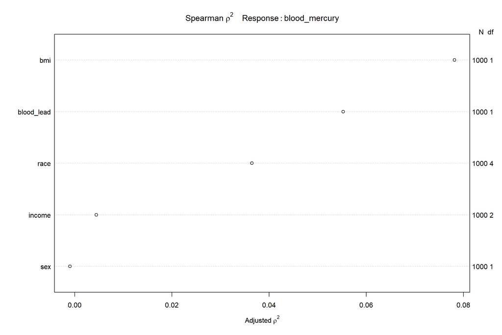

```r
plot(Hmisc::spearman2(blood_mercury ~ bmi + race + income + sex + blood_lead, data = blood_metal_data))
```

Looks like we should consider a nonlinear term for `bmi` and perhaps also `blood_lead`.

```r
d <- datadist(blood_metal_data)
options(datadist = "d")

nonlinear_model <- ols(blood_mercury ~ rcs(bmi, 4) + rcs(blood_lead, 4) + race + income + sex, data = blood_metal_data, x = T, y = T)
summary.lm(nonlinear_model)
```

```
Call:
ols(formula = blood_mercury ~ rcs(bmi, 4) + rcs(blood_lead, 4) +
    race + income + sex, data = blood_metal_data, x = T, y = T)

Residuals:
    Min      1Q  Median      3Q     Max
-2.9901 -0.7055 -0.2552  0.2442 17.7141

Coefficients:
                       Estimate Std. Error t value Pr(>|t|)
Intercept              -1.90956    0.87717  -2.177  0.02972 *
bmi                     0.12645    0.04551   2.778  0.00557 **
bmi'                   -0.31034    0.22199  -1.398  0.16243
bmi''                   0.50324    0.46186   1.090  0.27615
blood_lead             -0.49692    0.67791  -0.733  0.46372
blood_lead'            20.60767    8.05790   2.557  0.01069 *
blood_lead''          -40.62428   14.80048  -2.745  0.00616 **
race=Mexican American   0.06274    0.16889   0.372  0.71034
race=Other Hispanic     0.24598    0.18562   1.325  0.18544
race=Black              0.06287    0.16159   0.389  0.69730
race=Other              1.50162    0.18357   8.180 8.69e-16 ***
income=Middle           0.08959    0.13410   0.668  0.50423
income=High             0.28650    0.15140   1.892  0.05873 .
sex=Female             -0.09650    0.11567  -0.834  0.40432
---
Signif. codes:  0 '***' 0.001 '**' 0.01 '*' 0.05 '.' 0.1 ' ' 1

Residual standard error: 1.772 on 986 degrees of freedom
Multiple R-squared:  0.1583,    Adjusted R-squared:  0.1472
F-statistic: 14.26 on 13 and 986 DF,  p-value: < 2.2e-16
```

It appears that restricted cubic splines on both `bmi` and `blood_lead` contribute meaningfully to the predictive power of the model. It also appears that `income` and `sex` are not contributing much to the predictive power of our model, which is unfortunate. Let’s compare this to the simple linear model to see how much the nonlinear terms improve our predictions:

```r
summary.lm(lm(blood_mercury ~ bmi + blood_lead + race + income + sex, data = blood_metal_data))
```

```
Call:
lm(formula = blood_mercury ~ bmi + blood_lead + race + income +
    sex, data = blood_metal_data)

Residuals:
    Min      1Q  Median      3Q     Max
-4.1705 -0.5895 -0.2969  0.0781 18.2869

Coefficients:
                      Estimate Std. Error t value Pr(>|t|)
(Intercept)          -0.109974   0.255658  -0.430  0.66717
bmi                   0.029445   0.007667   3.841  0.00013 ***
blood_lead            0.202202   0.048931   4.132 3.89e-05 ***
raceMexican American -0.054972   0.172187  -0.319  0.74960
raceOther Hispanic    0.197134   0.189935   1.038  0.29957
raceBlack             0.042071   0.165427   0.254  0.79930
raceOther             1.575872   0.188194   8.374  < 2e-16 ***
incomeMiddle          0.037891   0.137211   0.276  0.78249
incomeHigh            0.166412   0.154542   1.077  0.28183
sexFemale            -0.116060   0.118669  -0.978  0.32831
---
Signif. codes:  0 '***' 0.001 '**' 0.01 '*' 0.05 '.' 0.1 ' ' 1

Residual standard error: 1.821 on 990 degrees of freedom
Multiple R-squared:  0.1076,    Adjusted R-squared:  0.09948
F-statistic: 13.26 on 9 and 990 DF,  p-value: < 2.2e-16
```

The nonlinear terms account for another 5% of the variation in `blood_mercury`, which is a decent improvement. The R-squared value is still low enough to not be of any practical significance, but it’s better than nothing.

Let’s visualize the role of these nonlinear terms with a nomogram:

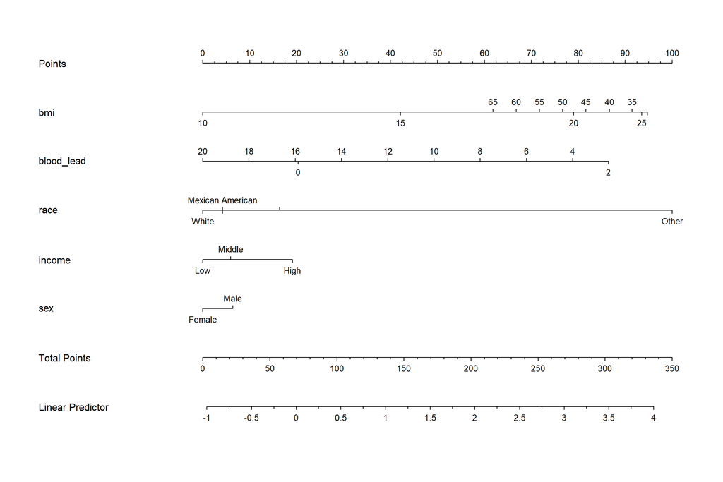

```r
plot(nomogram(nonlinear_model))
```

The BMI scale wraps around such that people with intermediate BMIs are predicted to have higher concentrations of mercury in their blood than people with very low or very high BMIs, holding all other predictors constant. The `blood_lead` scale also wraps around such that both people with very low and very high concentration of lead in the blood are predicted to have lower concentrations of mercury in their blood than people with intermediate concentration of lead in their blood, holding all other predictors constant.

According to this nomogram, a white male who makes more than $75,000, has no lead in his blood and has a BMI of 20 has 0 (white) + 5 (male) + 20 (high income) + 20 (no lead) + 79 (BMI of 20) = 124 points, so we would predict that he has 0.75 micrograms of mercury in every deciliter of his blood.

## 10.2 Effect Sizes

Let’s take a closer look at the effects each of our predictors have on the outcome:

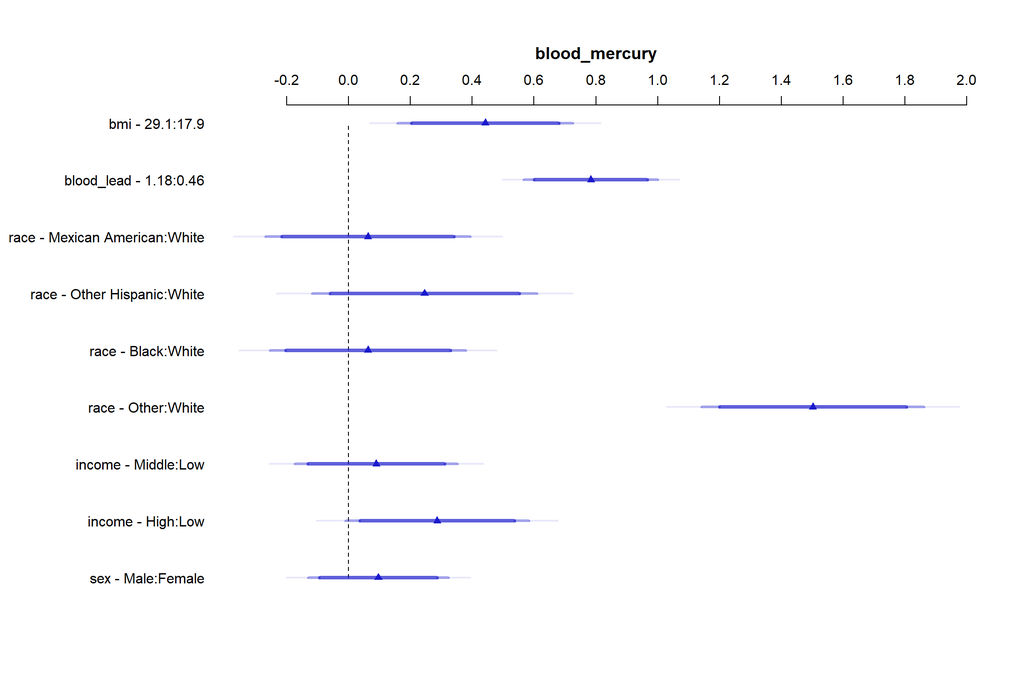

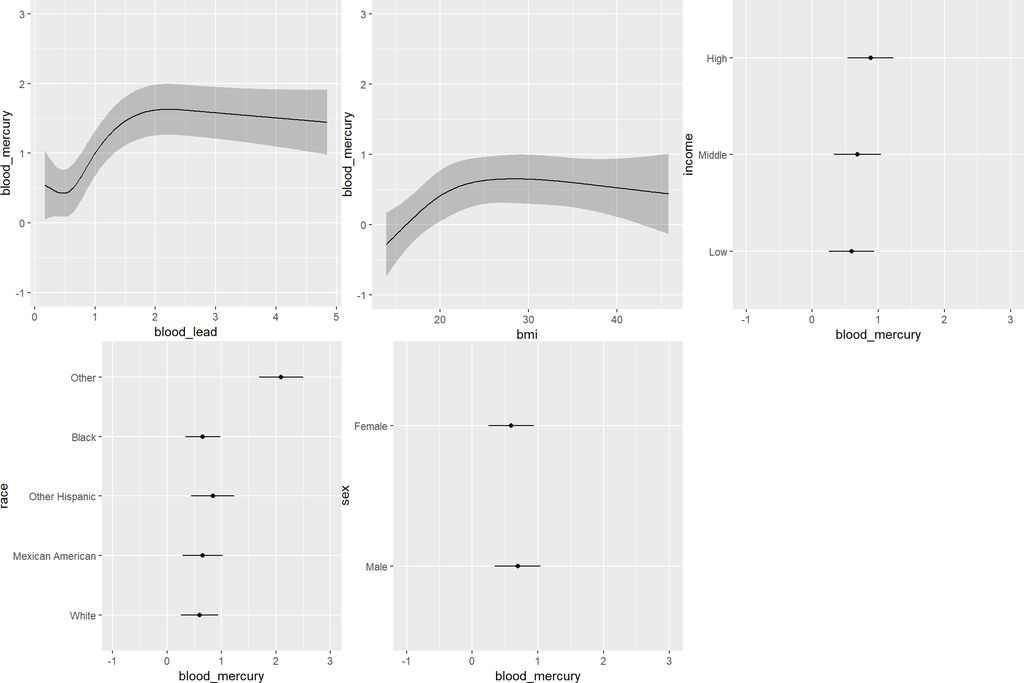

```r
plot(summary(nonlinear_model))
ggplot(Predict(nonlinear_model))
```

Interestingly, `race` tells us almost nothing about a sample’s `blood_mercury`, unless they’re neither White, Black or Hispanic; then we predict a much higher concentration of mercury in their blood. `blood_lead` and `bmi` predict that `blood_mercury` is low if they’re small, but otherwise predict a nearly constant value of `blood_mercury`. As we saw earlier, `income` and `sex` do not provide any meaningful information for predicting `blood_mercury`.

## 10.3 Quality of Model

Let’s assess the quality of our model by validating the associated statistics and checking our regression assumptions.

### 10.3.1 Validation

```r
set.seed(432)
validate(nonlinear_model)
```

```
          index.orig training   test optimism index.corrected  n
R-square      0.1583   0.1701 0.1438   0.0262          0.1320 40
MSE           3.0972   3.1843 3.1503   0.0339          3.0632 40
g             0.8429   0.8854 0.8153   0.0701          0.7727 40
Intercept     0.0000   0.0000 0.0681  -0.0681          0.0681 40
Slope         1.0000   1.0000 0.9302   0.0698          0.9302 40
```

It seems that the model was slightly overfit, as the R-squared dropped by 0.03 after validation. Even after validation, our model only explains 13% of the variation in `blood_mercury`, which is not an impressively large amount of variation.

### 10.3.2 Regression Assumptions

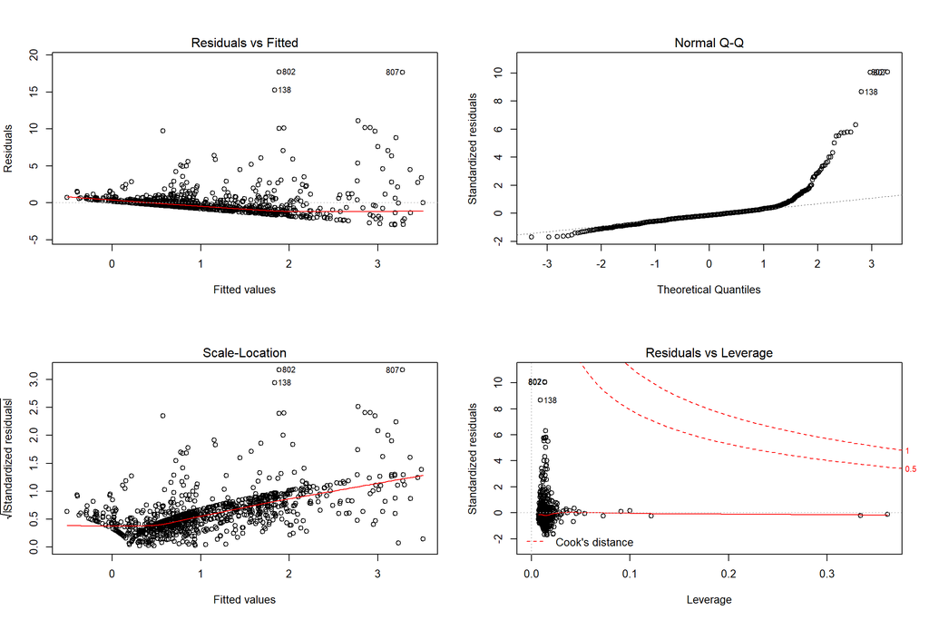

```r
par(mfrow = c(2,2))
plot(lm(blood_mercury ~ rcs(bmi, 4) + rcs(blood_lead, 4) + race + income + sex, data = blood_metal_data))
```

There’s a sharp lower bound evident on the residuals vs fitted plot, which is due to the fact that people can’t have a negative concentration of mercury in their blood. The model has higher residuals when it predicts higher values for the outcome, as evidenced by the slope in the scale-location plot, the heavy right tail on the QQ plot, and the faint fan shape (wider on the right) evident in the residuals vs fitted plot. The only two points that stand out on the leverage plot are not influential enough to merit further investigation, as they both fall decently far below the 0.5 Cook’s distance threshold.

# 11 Task 11: The Logistic Regression

## 11.1 LRM and ANOVA for our Model Before adding non-linear terms:

```r
d <- datadist(blood_metal_data)
options(datadist = "d")

LogRegModel_1 <- lrm(mercury_detection ~ blood_lead + bmi + sex + race + income,
            data = blood_metal_data,
            x = TRUE, y = TRUE)

LogRegModel_1
```

```
Logistic Regression Model

 lrm(formula = mercury_detection ~ blood_lead + bmi + sex + race +
     income, data = blood_metal_data, x = TRUE, y = TRUE)

                       Model Likelihood     Discrimination    Rank Discrim.
                          Ratio Test           Indexes           Indexes
 Obs          1000    LR chi2      72.62    R2       0.104    C       0.677
  0            247    d.f.             9    g        0.809    Dxy     0.355
  1            753    Pr(> chi2) <0.0001    gr       2.245    gamma   0.355
 max |deriv| 2e-08                          gp       0.130    tau-a   0.132
                                            Brier    0.173

                       Coef    S.E.   Wald Z Pr(>|Z|)
 Intercept             -1.3674 0.3604 -3.79  0.0001
 blood_lead             0.4115 0.1235  3.33  0.0009
 bmi                    0.0638 0.0115  5.55  <0.0001
 sex=Female             0.1657 0.1573  1.05  0.2923
 race=Mexican American  0.5399 0.2241  2.41  0.0160
 race=Other Hispanic    0.9408 0.2716  3.46  0.0005
 race=Black             0.4345 0.2129  2.04  0.0412
 race=Other             0.8267 0.2583  3.20  0.0014
 income=Middle         -0.0276 0.1790 -0.15  0.8775
 income=High            0.4489 0.2110  2.13  0.0333
```

```r
anova(LogRegModel_1)
```

```
                Wald Statistics          Response: mercury_detection

 Factor     Chi-Square d.f. P
 blood_lead 11.11      1    0.0009
 bmi        30.77      1    <.0001
 sex         1.11      1    0.2923
 race       18.70      4    0.0009
 income      6.07      2    0.0480
 TOTAL      61.03      9    <.0001
```

After running an ANOVA on our kitchen sink regression model, we find that the most useful predictors in our model are blood lead levels, BMI, and Race.

As for degrees of freedom, we can only spend 10-20 degrees of freedom on our model (N/P = 100 to N/P = 50), and as we can see, it already has 9 degrees of freedom. Therefore, we will create a Spearman Rho2 plot to decide which of our predictors we will fit a non-linear term on, since we already established that these are the predictors we want to have in our model. Having that non-linear term will allow us to spend as many degrees of freedom as we can without overfitting the model.

## 11.2 Spearman Rho2 Plot:

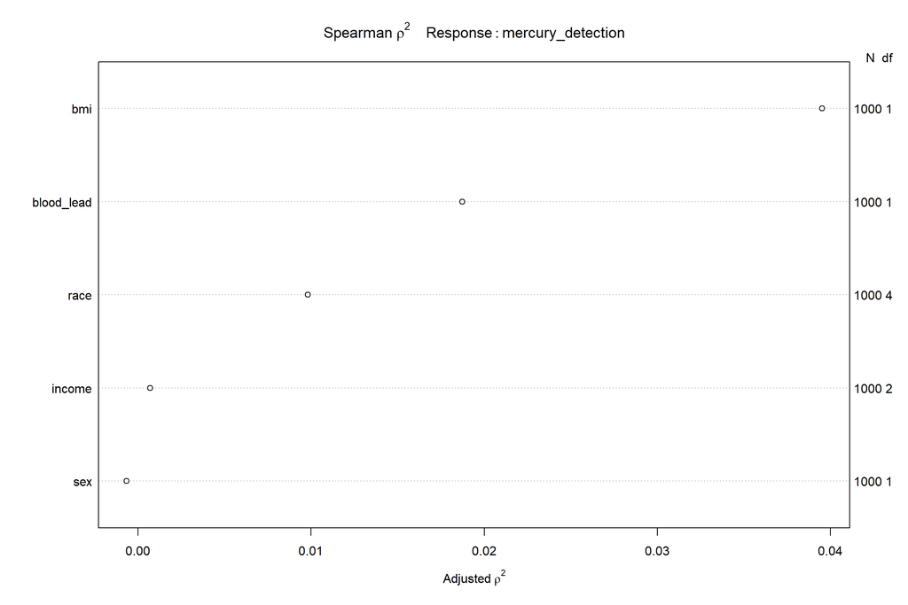

```r
plot(spearman2(mercury_detection ~ blood_lead + bmi + sex + race + income, data = blood_metal_data))
```

We want to stay as close to 10 degrees of freedom as we can, and since our model already contains 9, we will use a cubic spline with 3 knots on our bmi predictor, since it seems that it will be most useful there. As we can see above, the most useful variable to have a non-linear term applied to it is BMI, with it’s p2 furthest to the right.

## 11.3 Adding the Cubic Spline to the Model:

```r
LogRegModel_2 <- lrm(mercury_detection ~ blood_lead + rcs(bmi,3) + sex + race + income,
            data = blood_metal_data,
            x = TRUE, y = TRUE)

LogRegModel_2
```

```
Logistic Regression Model

 lrm(formula = mercury_detection ~ blood_lead + rcs(bmi, 3) +
     sex + race + income, data = blood_metal_data, x = TRUE, y = TRUE)

                       Model Likelihood     Discrimination    Rank Discrim.
                          Ratio Test           Indexes           Indexes
 Obs          1000    LR chi2      81.44    R2       0.116    C       0.689
  0            247    d.f.            10    g        0.819    Dxy     0.377
  1            753    Pr(> chi2) <0.0001    gr       2.269    gamma   0.377
 max |deriv| 2e-08                          gp       0.137    tau-a   0.140
                                            Brier    0.172

                       Coef    S.E.   Wald Z Pr(>|Z|)
 Intercept             -2.7601 0.5906 -4.67  <0.0001
 blood_lead             0.3676 0.1229  2.99  0.0028
 bmi                    0.1400 0.0280  5.00  <0.0001
 bmi'                  -0.1109 0.0362 -3.06  0.0022
 sex=Female             0.1839 0.1585  1.16  0.2461
 race=Mexican American  0.5570 0.2255  2.47  0.0135
 race=Other Hispanic    0.9402 0.2731  3.44  0.0006
 race=Black             0.4593 0.2145  2.14  0.0322
 race=Other             0.8475 0.2616  3.24  0.0012
 income=Middle         -0.0216 0.1803 -0.12  0.9047
 income=High            0.4708 0.2127  2.21  0.0269
```

```r
anova(LogRegModel_2)
```

```
                Wald Statistics          Response: mercury_detection

 Factor     Chi-Square d.f. P
 blood_lead  8.95       1   0.0028
 bmi        42.77       2   <.0001
  Nonlinear  9.38       1   0.0022
 sex         1.35       1   0.2461
 race       18.88       4   0.0008
 income      6.44       2   0.0399
 TOTAL      71.28      10   <.0001
```

## 11.4 Validation of our Kitchen Sink Model and our New Model Using 100 Bootstrap Replications:

```r
set.seed(03102019)
validate(LogRegModel_1, B = 100)
```

```
          index.orig training   test optimism index.corrected   n
Dxy           0.3549   0.3677 0.3346   0.0331          0.3218 100
R2            0.1041   0.1137 0.0931   0.0206          0.0834 100
Intercept     0.0000   0.0000 0.1041  -0.1041          0.1041 100
Slope         1.0000   1.0000 0.8983   0.1017          0.8983 100
Emax          0.0000   0.0000 0.0426   0.0426          0.0426 100
D             0.0716   0.0788 0.0637   0.0151          0.0565 100
U            -0.0020  -0.0020 0.0007  -0.0027          0.0007 100
Q             0.0736   0.0808 0.0630   0.0179          0.0557 100
B             0.1730   0.1719 0.1748  -0.0029          0.1760 100
g             0.8087   0.8550 0.7553   0.0997          0.7089 100
gp            0.1298   0.1352 0.1224   0.0128          0.1170 100
```

```r
validate(LogRegModel_2, B = 100)
```

```
          index.orig training   test optimism index.corrected   n
Dxy           0.3772   0.3938 0.3579   0.0359          0.3413 100
R2            0.1162   0.1293 0.1053   0.0240          0.0922 100
Intercept     0.0000   0.0000 0.1125  -0.1125          0.1125 100
Slope         1.0000   1.0000 0.8962   0.1038          0.8962 100
Emax          0.0000   0.0000 0.0448   0.0448          0.0448 100
D             0.0804   0.0903 0.0725   0.0177          0.0627 100
U            -0.0020  -0.0020 0.0009  -0.0029          0.0009 100
Q             0.0824   0.0923 0.0717   0.0206          0.0618 100
B             0.1716   0.1699 0.1735  -0.0035          0.1751 100
g             0.8194   0.8728 0.7770   0.0958          0.7236 100
gp            0.1371   0.1443 0.1304   0.0139          0.1232 100
```

## 11.5 Plot Effects for Our Model with the Non-Linear Term:

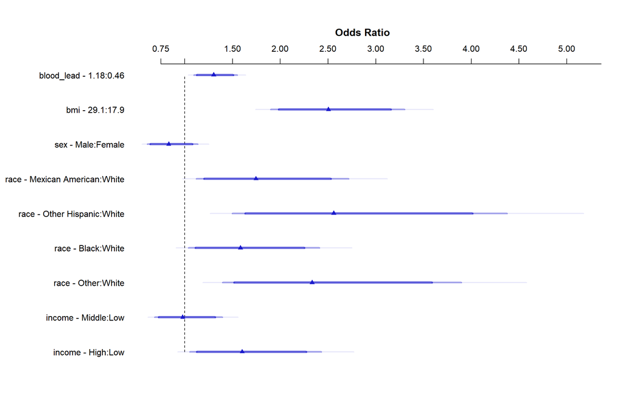

```r
plot(summary(LogRegModel_2))
```

```r
summary(LogRegModel_2)
```

```
             Effects              Response : mercury_detection

 Factor                        Low   High  Diff. Effect    S.E.
 blood_lead                     0.46  1.18  0.72  0.264660 0.088476
  Odds Ratio                    0.46  1.18  0.72  1.303000       NA
 bmi                           17.90 29.10 11.20  0.917830 0.141080
  Odds Ratio                   17.90 29.10 11.20  2.503900       NA
 sex - Male:Female              2.00  1.00    NA -0.183870 0.158530
  Odds Ratio                    2.00  1.00    NA  0.832040       NA
 race - Mexican American:White  1.00  2.00    NA  0.557020 0.225490
  Odds Ratio                    1.00  2.00    NA  1.745500       NA
 race - Other Hispanic:White    1.00  3.00    NA  0.940170 0.273100
  Odds Ratio                    1.00  3.00    NA  2.560400       NA
 race - Black:White             1.00  4.00    NA  0.459270 0.214460
  Odds Ratio                    1.00  4.00    NA  1.582900       NA
 race - Other:White             1.00  5.00    NA  0.847460 0.261580
  Odds Ratio                    1.00  5.00    NA  2.333700       NA
 income - Middle:Low            1.00  2.00    NA -0.021582 0.180290
  Odds Ratio                    1.00  2.00    NA  0.978650       NA
 income - High:Low              1.00  3.00    NA  0.470840 0.212730
  Odds Ratio                    1.00  3.00    NA  1.601300       NA
 Lower 0.95 Upper 0.95
  0.091254  0.43807
  1.095500  1.54970
  0.641330  1.19430
  1.899000  3.30140
 -0.494570  0.12683
  0.609830  1.13520
  0.115070  0.99898
  1.122000  2.71550
  0.404900  1.47540
  1.499200  4.37290
  0.038934  0.87961
  1.039700  2.41000
  0.334760  1.36020
  1.397600  3.89680
 -0.374940  0.33177
  0.687330  1.39340
  0.053890  0.88779
  1.055400  2.42980
```

Our final model that we landed was the model that included the restricted cubic spline on BMI.

Holding all else constant, Sex did not seem to have an impact on whether one had blood mercury levels above the detection limit. In addition, having a family income of 35,000-74,999 dollars per year did not seem to have a significant difference in odds of having blood mercury levels above the detection limit when compared to people living with family incomes of less than 35,000 dollars per year.

## 11.6 Nomogram:

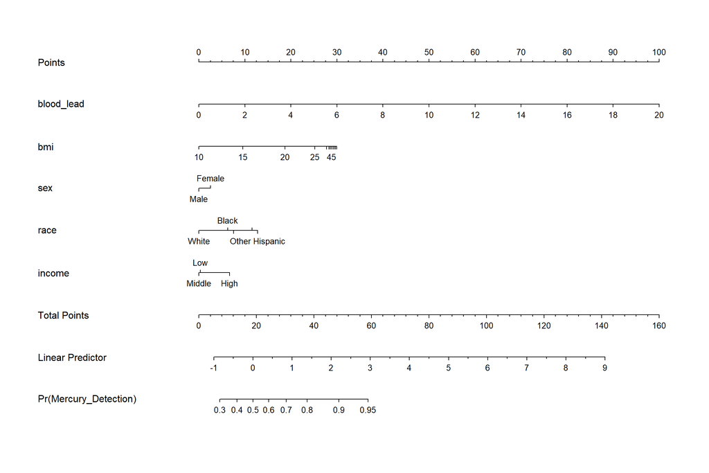

```r
plot(nomogram(LogRegModel_2, fun=plogis, fun.at=c(0.05, seq(0.1, 0.9, by = 0.1), 0.95), funlabel = "Pr(Mercury_Detection)"))
```

# 12 Task 12: The Reflection